# Hotel dataset analysis

Datascience Tools, February 2025  
Luka Skeledžija

## Introduction

This analysis explores a dataset containing 119,390 hotel bookings recorded between July 2015 and August 2017 from two hotels: a City Hotel and a Resort Hotel. The data includes both successful stays and cancellations, providing insights into booking patterns and hotel operations. While customer identification details were removed for privacy, the dataset includes synthetic personal information to maintain data structure. Through this analysis, we aim to uncover meaningful patterns and seasonal trends.

> You can download the dataset yourself from Kaggle → [🔗 Hotel Booking Dataset](https://www.kaggle.com/datasets/mojtaba142/hotel-booking/data)

## What do we want achieve?

1. Can we see any signs of seasonality in the dataset?
2. Visualize the distribution of the total length of the stays.
3. Find out what's the reservation with the biggest number of guests that was not canceled?
4. Find out what is the cancellation rate of the bookings as a function of lead time?

## Structure of data

First, we will look into the column structure of our dataset.

```
Number of rows: 119390
```

|  | hotel | is_canceled | lead_time | arrival_date_year | arrival_date_month | arrival_date_week_number | arrival_date_day_of_month | stays_in_weekend_nights | stays_in_week_nights | adults | children | babies | is_repeated_guest | previous_cancellations | previous_bookings_not_canceled | reserved_room_type | assigned_room_type |
| --- | --- | --- | --- | --- | --- | --- | --- | --- | --- | --- | --- | --- | --- | --- | --- | --- | --- |
| 0 | Resort Hotel | 0 | 342 | 2015 | July | 27 | 1 | 0 | 0 | 2 | 0.0 | 0 | 0 | 0 | 0 | C | C |
| 1 | Resort Hotel | 0 | 737 | 2015 | July | 27 | 1 | 0 | 0 | 2 | 0.0 | 0 | 0 | 0 | 0 | C | C |
| 2 | Resort Hotel | 0 | 7 | 2015 | July | 27 | 1 | 0 | 1 | 1 | 0.0 | 0 | 0 | 0 | 0 | A | C |
| ... | ... | ... | ... | ... | ... | ... | ... | ... | ... | ... | ... | ... | ... | ... | ... | ... | ... |
| 7 | Resort Hotel | 0 | 9 | 2015 | July | 27 | 1 | 0 | 2 | 2 | 0.0 | 0 | 0 | 0 | 0 | C | C |
| 8 | Resort Hotel | 1 | 85 | 2015 | July | 27 | 1 | 0 | 3 | 2 | 0.0 | 0 | 0 | 0 | 0 | A | A |
| 9 | Resort Hotel | 1 | 75 | 2015 | July | 27 | 1 | 0 | 3 | 2 | 0.0 | 0 | 0 | 0 | 0 | D | D |

Let's check the individual columns for datatype and null values.

| Column name | Data type | Null count | Unique count |
| --- | --- | --- | --- |
| hotel | object | 0 | 2 |
| is_canceled | int64 | 0 | 2 |
| lead_time | int64 | 0 | 479 |
| arrival_date_year | int64 | 0 | 3 |
| arrival_date_month | object | 0 | 12 |
| arrival_date_week_number | int64 | 0 | 53 |
| arrival_date_day_of_month | int64 | 0 | 31 |
| stays_in_weekend_nights | int64 | 0 | 17 |
| stays_in_week_nights | int64 | 0 | 35 |
| adults | int64 | 0 | 14 |
| children | float64 | 4 | 5 |
| babies | int64 | 0 | 5 |
| is_repeated_guest | int64 | 0 | 2 |
| previous_cancellations | int64 | 0 | 15 |
| previous_bookings_not_canceled | int64 | 0 | 73 |
| reserved_room_type | object | 0 | 10 |
| assigned_room_type | object | 0 | 12 |

> More detailed descriptions on Kaggle → [Hotel Booking Dataset](https://www.kaggle.com/datasets/mojtaba142/hotel-booking/data)

Interestingly, number of children is a `float64` 🤔 ... but based on grouping it seems that this is just a quirk. The column is always a whole number, but stored as a float.

| children | count |
| --- | --- |
| 0.0 | 110796 |
| 1.0 | 4861 |
| 2.0 | 3652 |
| 3.0 | 76 |
| 10.0 | 1 |

## Seasonality in the data

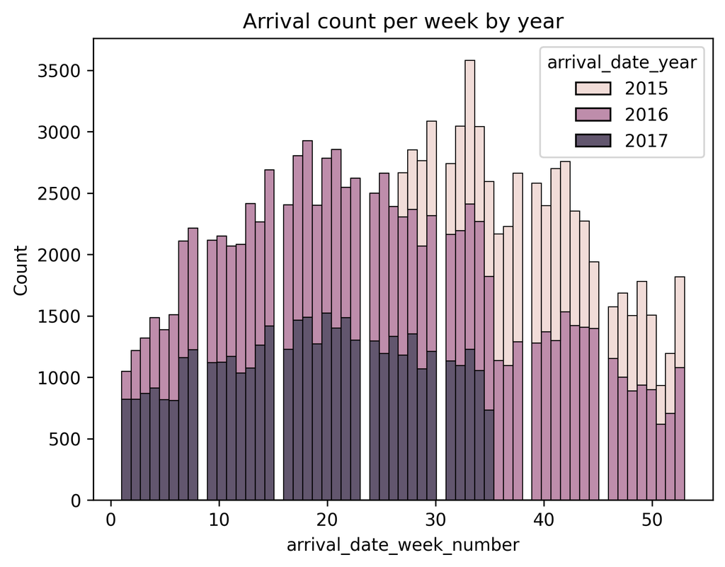

Important takeaways:

- We only have 1 full year of data (2016), other two are only partial
- For some of the weeks numbers there is no data - that's weird! Since we have 2 different hotels in our dataset, something must have happened to our dataset or there are some other unexpected factors (e.g. collective vacations).

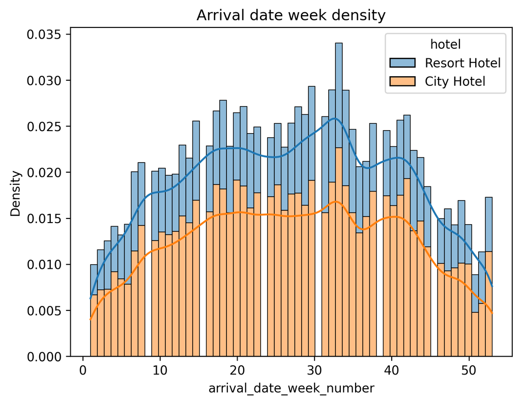

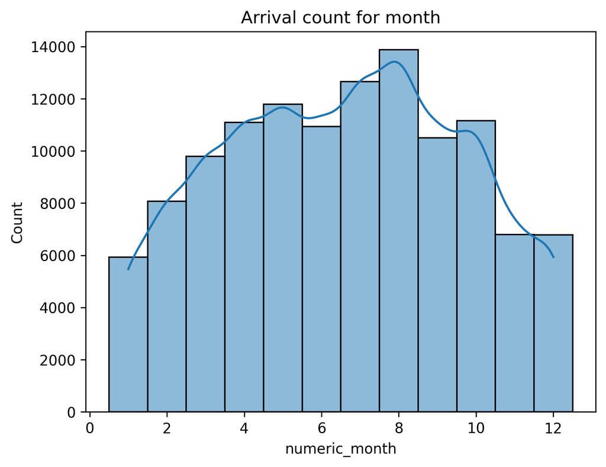

## Length of stay - distribution

Visualize the distribution of the total length of the stays.

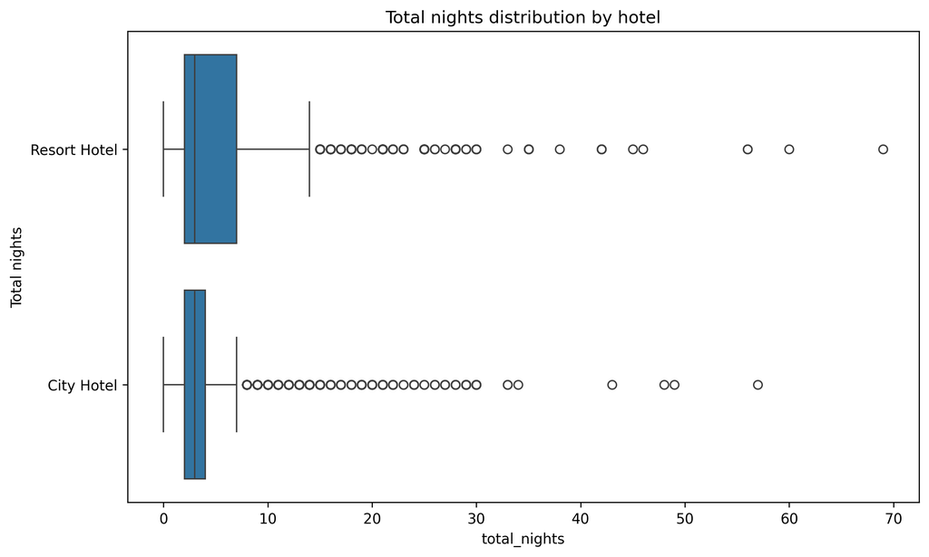

Key takeaways:

- There are *many* outliers in both cases!
- Plotting distributions will not be easy

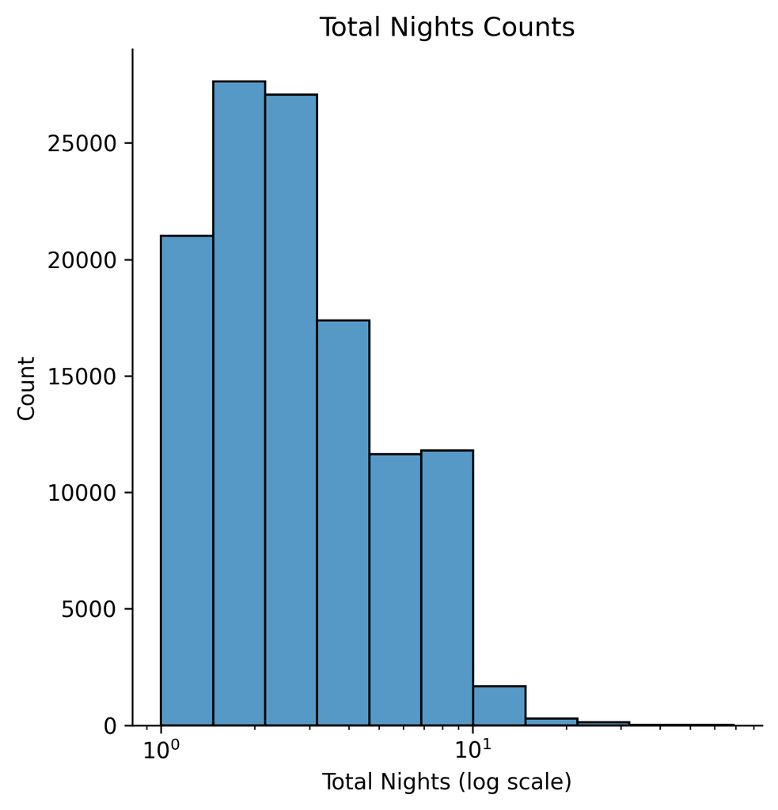

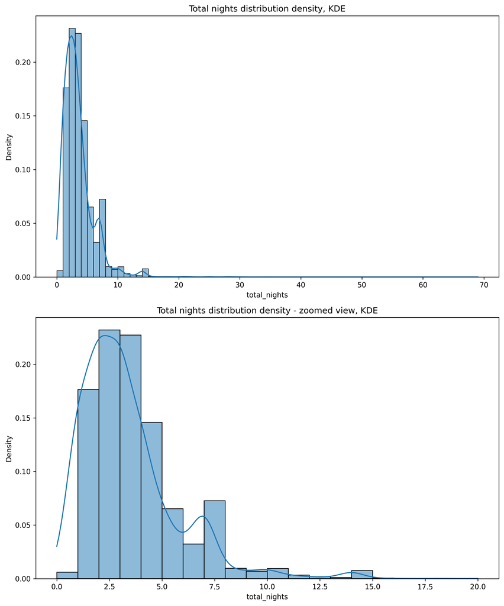

## Biggest group of guests

Find out what's the reservation with the biggest number of guests that was not canceled.

| total_guests | count |
| --- | --- |
| 12.0 | 1 |
| 10.0 | 1 |
| 5.0 | 103 |
| 4.0 | 2283 |
| 3.0 | 7118 |
| 2.0 | 49479 |
| 1.0 | 16026 |
| 0.0 | 155 |

The biggest not cancelled stay was with 12 guests as shown below.

| hotel | is_canceled | lead_time | arrival_date_year | arrival_date_month | arrival_date_week_number | arrival_date_day_of_month | stays_in_weekend_nights | stays_in_week_nights | adults | children | babies | is_repeated_guest | previous_cancellations | previous_bookings_not_canceled | reserved_room_type | assigned_room_type | numeric_month | total_nights | total_guests |
| --- | --- | --- | --- | --- | --- | --- | --- | --- | --- | --- | --- | --- | --- | --- | --- | --- | --- | --- | --- |
| City Hotel | 0 | 37 | 2016 | January | 3 | 12 | 0 | 2 | 2 | 0.0 | 10 | 0 | 0 | 0 | D | D | 1 | 2 | 12.0 |

## Cancellation rate as a function of lead time

We'll plot the cancellation rate of the bookings as a function of lead time. We suspect that bookings made further in advance are more likely to be cancelled.

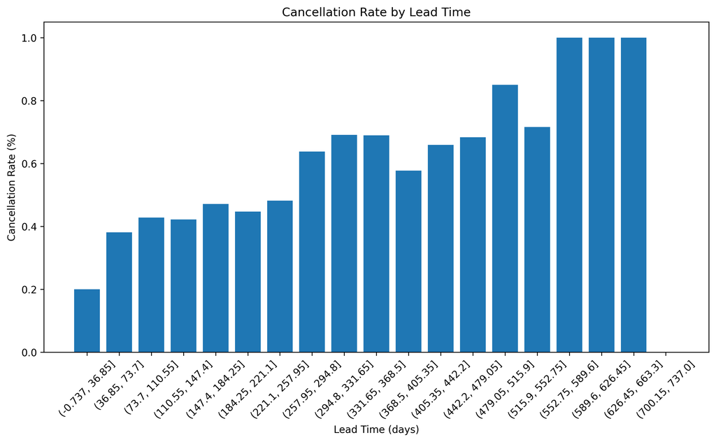

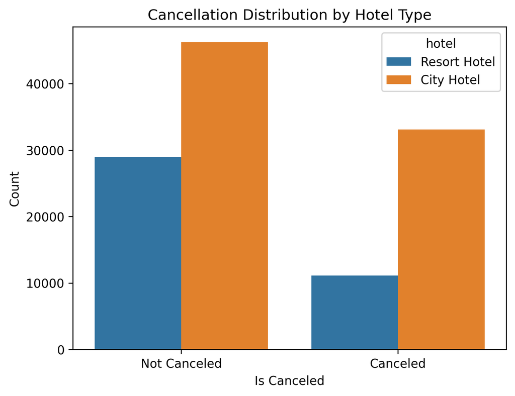

Key takeaways:

- A big percentage of bookings are cancelled
- City hotel seems to have a higher rate of cancellations. Could make sense if people travel to cities more for business and their plans change more often.

## Conclusions

As a result of this exploratory data analysis we have observed some seasonality trends in the dataset, mainly in terms of number of bookings in the summer. Which is probably to be expected. Next we visualized the distribution of the total lengths of stay. The data turned out to include many outliers. Something to be aware of. We also found the reservation with the biggest number of guests that has not been cancelled (12). We also discovered, that the cancellation rate of bookings increases with as a function of lead time.

Luka Skeledžija, [Github source 🔗](https://github.com/lukaske/datascience-tools/blob/main/hotels-analysis.ipynb), 2025